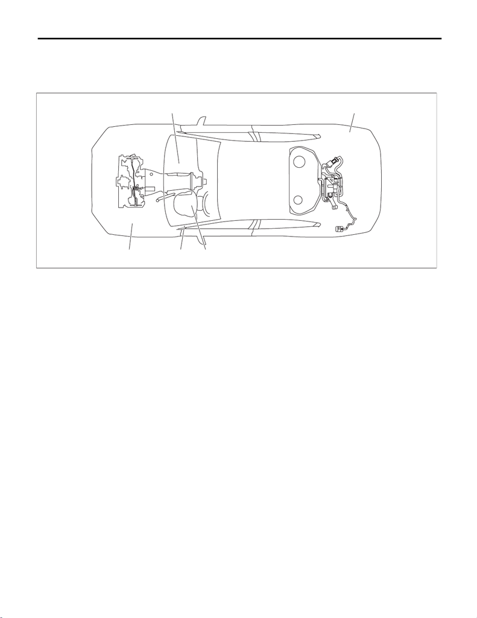

EN(STI)(diag)-8

Electrical Component Location

ENGINE (DIAGNOSTICS)

4. Electrical Component Location

A: LOCATION

1. CONTROL MODULE

(1) Engine control module (ECM) (3) Delivery mode fuse (5) Fuel pump control unit

(2) Malfunction indicator light (4) Data link connector

EN-10836

(4) (2)(3)

(1) (5)

[figure not shown]

EN(STI)(diag)-9

Electrical Component Location

ENGINE (DIAGNOSTICS)

EN-10776

(1)

CHECK

ENGINE

(2)

CHECK

ENGINE

EN-10831

EN-10837

(3)

EN-10212

EN-10971

(5)

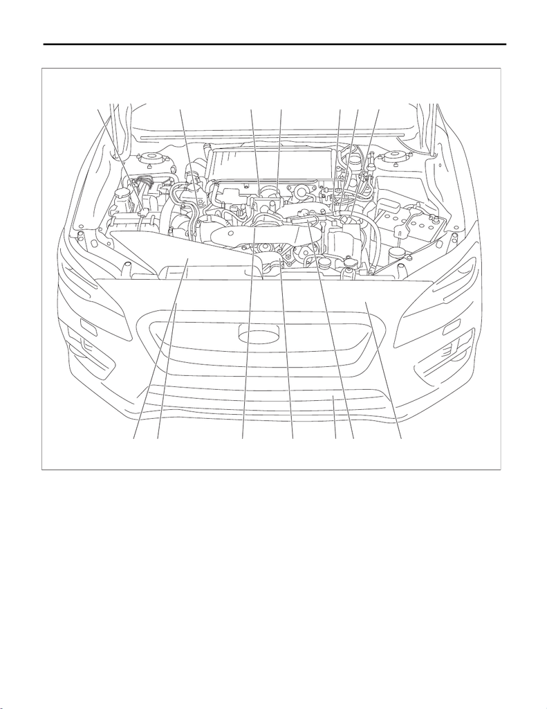

EN(STI)(diag)-10

Electrical Component Location

ENGINE (DIAGNOSTICS)

2. SENSOR

(1) Manifold absolute pressure sen-

sor

(5) Intake camshaft position sensor (9) Tumble generator valve ASSY

(with built-in sensor)

(2) Engine coolant temperature sen-

sor

(6) Exhaust camshaft position sensor (10) Secondary air combination valve

LH (with built-in sensor)

(3) Electronic throttle control (7) Crankshaft position sensor (11) Ambient sensor

(4) Knock sensor (8) Mass air flow and intake air temper-

ature sensor

EN-10838

(9) (11)(7) (6)

(10) (9)(1)(8) (5)

(2) (4)

(3)(5)

(6)

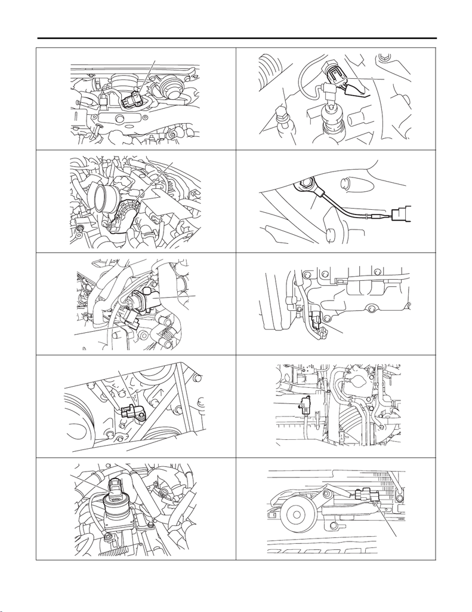

EN(STI)(diag)-11

Electrical Component Location

ENGINE (DIAGNOSTICS)

EN-06418

(1)

EN-00295

(2)

EN-06419

(3)

EN-02169

(4)

EN-10785

(5)

(9)

EN-01929

(6)

EN-01930

(7)

EN-10784

(8)

EN-06421

(10)

EN-10887

(11)

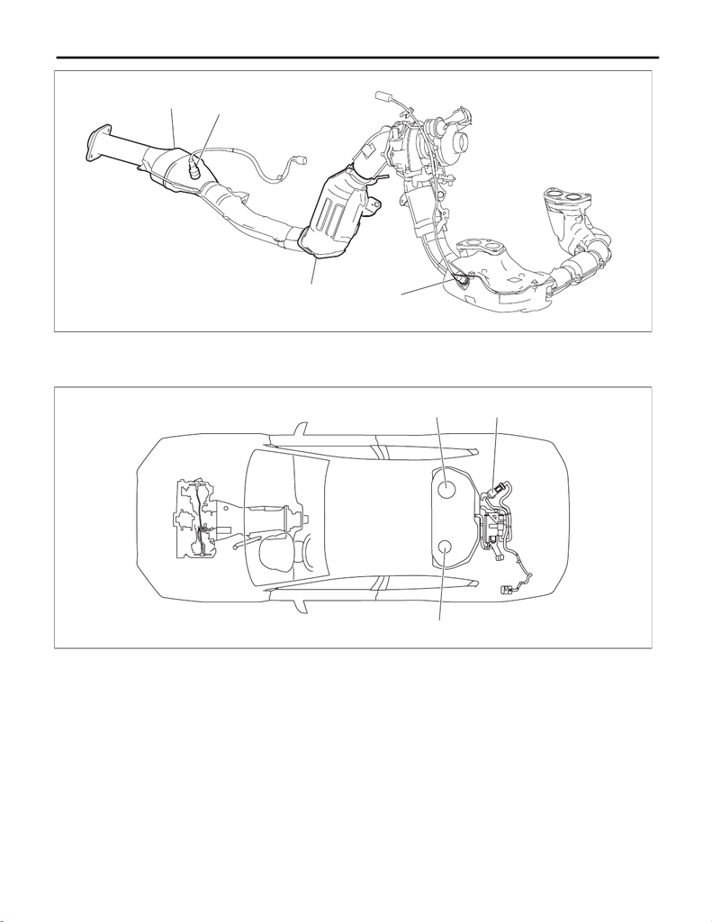

EN(STI)(diag)-12

Electrical Component Location

ENGINE (DIAGNOSTICS)

(1) Front oxygen (A/F) sensor (3) Rear oxygen sensor (4) Rear catalytic converter

(2) Front catalytic converter

(1) Leak check valve ASSY (with

built-in pressure sensor)

(2) Fuel level sensor (3) Fuel sub level sensor

EN-10782

(4)

(2)

(1)

(3)

EN-10825

(1)

(3)

(2)

[figure not shown]

EN(STI)(diag)-13

Electrical Component Location

ENGINE (DIAGNOSTICS)

EN-10882

(1)

EN-09239

(2)

EN-09240

(3)

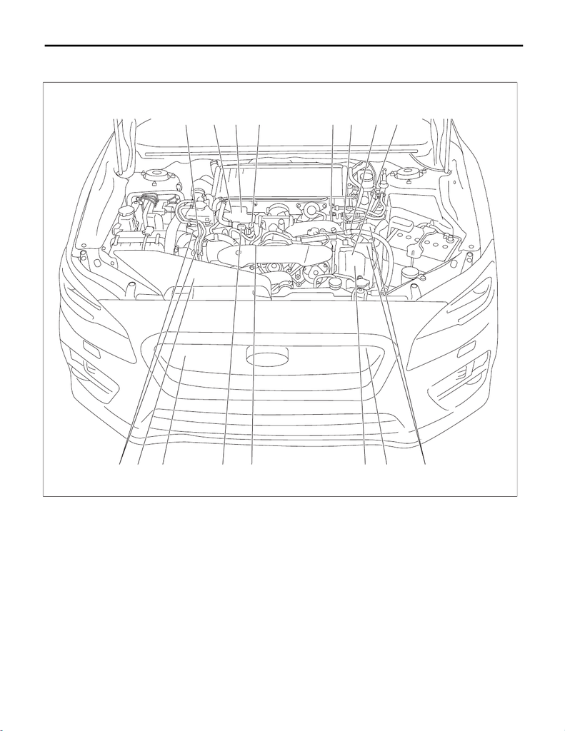

EN(STI)(diag)-14

Electrical Component Location

ENGINE (DIAGNOSTICS)

3. SOLENOID VALVE, ACTUATOR, EMISSION CONTROL SYSTEM PARTS AND IGNITION

SYSTEM PARTS

(1) Wastegate control solenoid valve (5) Exhaust oil flow control solenoid

valve

(9) Tumble generator valve ASSY

(2) Purge control solenoid valve 1 (6) Secondary air pump (10) Purge control solenoid valve 2

(3) Ignition coil (7) Secondary air combination valve

RH

(11) Leak diagnosis connector 1

(4) Intake oil flow control solenoid

valve

(8) Secondary air combination valve

LH

(12) Leak diagnosis connector 2

EN-10840

(3)(3)

(9)

(9)

(4)

(2) (5)

(10) (7)(1) (8)

(12) (6)

(11)(4)

(5)

[figure not shown]

EN(STI)(diag)-15

Electrical Component Location

ENGINE (DIAGNOSTICS)

EN-06426

(1)

EN-10777

(11) (10)

(2)

EN-01936

(3)

EN-01937

(4)

EN-06460

(5)

EN-05586

(6)

EN-06428

(7)

(8)

EN-04992

(9)

EN-10778

(12)

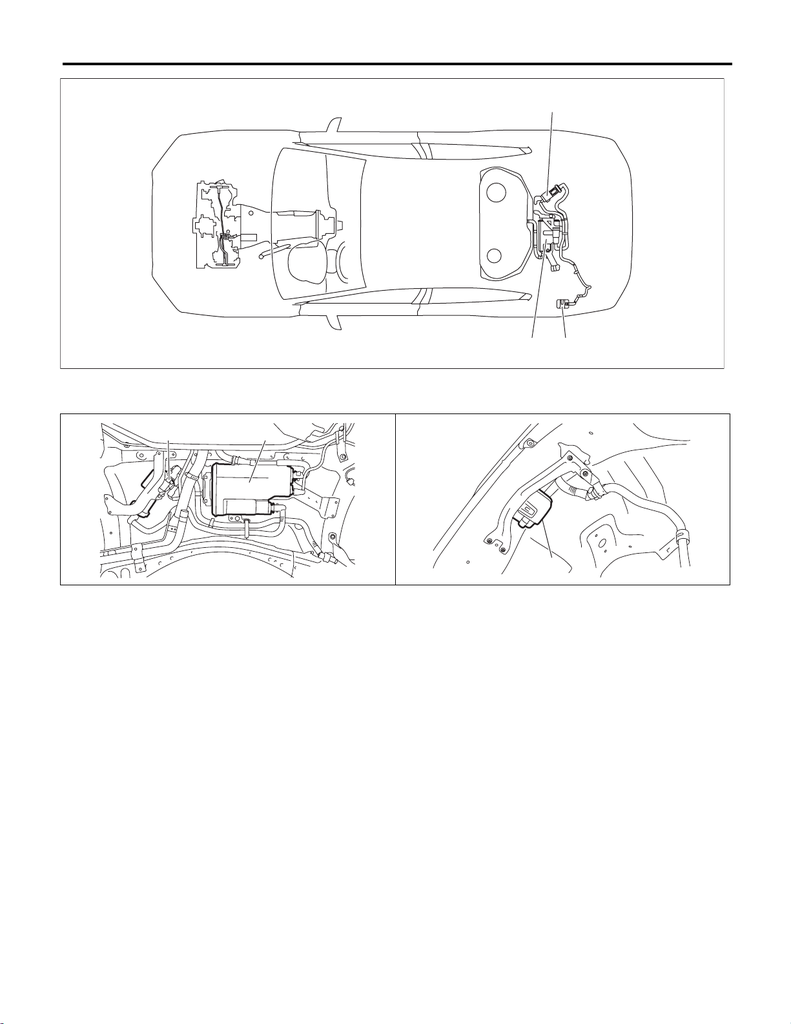

EN(STI)(diag)-16

Electrical Component Location

ENGINE (DIAGNOSTICS)

(1) Leak check valve ASSY (2) Canister (3) Drain filter

EN-10826

(2)

(1)

(3)

EN-10786

(1)

(2)

EN-10783

(3)

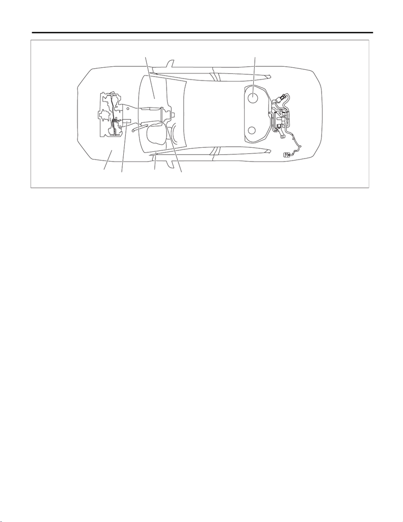

EN(STI)(diag)-17

Electrical Component Location

ENGINE (DIAGNOSTICS)

(1) Starter (7) Secondary air combination valve

relay 2

(13) Starter relay 1

(2) Fuel pump (8) Secondary air pump relay (14) Starter cut relay (model with push

button start)

(3) Radiator main fan relay 1 (9) Main relay (15) IG relay 1 (push button start)

(model with push button start)

(4) Radiator main fan relay 2 (10) Fuel pump relay (16) Starter relay (push button start)

(model with push button start)

(5) Radiator sub fan relay (11) A/F, oxygen sensor relay (17) Push button ignition switch (model

with push button start)

(6) Secondary air combination valve

relay 1

(12) Electronic throttle control relay

EN-10842

(3)(4)(5)

(6)(7)(8)

(9)(10)

(1)

(11)(12)(13)

(14)(15)(16)

(17)

(2)

[figure not shown]

EN(STI)(diag)-18

Electrical Component Location

ENGINE (DIAGNOSTICS)

4. TRANSMISSION

(1) Neutral position switch

EN-10780

(1)

EN-02093

(2)

EN-10843

(6)(3)

(4)

(5)

(7) (8)

EN-10844

(9)

(10)

EN-10845

(11)

(12)

(13)

(14)

(15)

(16)

EN-10839

(17)

EN-10885

(1)